# Project Python Foundations: FoodHub Data Analysis

**Marks: 60**

### Context

The number of restaurants in New York is increasing day by day. Lots of students and busy professionals rely on those restaurants due to their hectic lifestyles. Online food delivery service is a great option for them. It provides them with good food from their favorite restaurants. A food aggregator company FoodHub offers access to multiple restaurants through a single smartphone app.

The app allows the restaurants to receive a direct online order from a customer. The app assigns a delivery person from the company to pick up the order after it is confirmed by the restaurant. The delivery person then uses the map to reach the restaurant and waits for the food package. Once the food package is handed over to the delivery person, he/she confirms the pick-up in the app and travels to the customer's location to deliver the food. The delivery person confirms the drop-off in the app after delivering the food package to the customer. The customer can rate the order in the app. The food aggregator earns money by collecting a fixed margin of the delivery order from the restaurants.

### Objective

The food aggregator company has stored the data of the different orders made by the registered customers in their online portal. They want to analyze the data to get a fair idea about the demand of different restaurants which will help them in enhancing their customer experience. Suppose you are hired as a Data Scientist in this company and the Data Science team has shared some of the key questions that need to be answered. Perform the data analysis to find answers to these questions that will help the company to improve the business.

### Data Description

The data contains the different data related to a food order. The detailed data dictionary is given below.

### Data Dictionary

- order_id: Unique ID of the order
- customer_id: ID of the customer who ordered the food
- restaurant_name: Name of the restaurant
- cuisine_type: Cuisine ordered by the customer
- cost: Cost of the order
- day_of_the_week: Indicates whether the order is placed on a weekday or weekend (The weekday is from Monday to Friday and the weekend is Saturday and Sunday)
- rating: Rating given by the customer out of 5
- food_preparation_time: Time (in minutes) taken by the restaurant to prepare the food. This is calculated by taking the difference between the timestamps of the restaurant's order confirmation and the delivery person's pick-up confirmation.
- delivery_time: Time (in minutes) taken by the delivery person to deliver the food package. This is calculated by taking the difference between the timestamps of the delivery person's pick-up confirmation and drop-off information

### Let us start by importing the required libraries

```python
# Installing the libraries with the specified version.
!pip install numpy==2.0.2 pandas==2.2.2 matplotlib==3.10.0 seaborn==0.13.2 -q --user
```

```python
from google.colab import drive
drive.mount('/content/drive')
```

```python
# import libraries for data manipulation
import numpy as np
import pandas as pd

# import libraries for data visualization
import matplotlib.pyplot as plt
import seaborn as sns
```

### Understanding the structure of the data

```python
from google.colab import drive
drive.mount('/content/drive')
```

```python
# read the data
df = pd.read_csv('/content/drive/MyDrive/Project - FoodHub/foodhub_order.csv')
# returns the first 5 rows
df.head()
```

|  | order_id | customer_id | restaurant_name | cuisine_type | cost_of_the_order | day_of_the_week | rating | food_preparation_time | delivery_time |
| --- | --- | --- | --- | --- | --- | --- | --- | --- | --- |
| 0 | 1477147 | 337525 | Hangawi | Korean | 30.75 | Weekend | Not given | 25 | 20 |
| 1 | 1477685 | 358141 | Blue Ribbon Sushi Izakaya | Japanese | 12.08 | Weekend | Not given | 25 | 23 |
| 2 | 1477070 | 66393 | Cafe Habana | Mexican | 12.23 | Weekday | 5 | 23 | 28 |
| 3 | 1477334 | 106968 | Blue Ribbon Fried Chicken | American | 29.20 | Weekend | 3 | 25 | 15 |
| 4 | 1478249 | 76942 | Dirty Bird to Go | American | 11.59 | Weekday | 4 | 25 | 24 |

- Just from the first couple of rows, there are a couple of ratings not provided (missing data) or customer chose not to provide rating after receiving food package.

```python
df.tail()
```

|  | order_id | customer_id | restaurant_name | cuisine_type | cost_of_the_order | day_of_the_week | rating | food_preparation_time | delivery_time |
| --- | --- | --- | --- | --- | --- | --- | --- | --- | --- |
| 1893 | 1476701 | 292602 | Chipotle Mexican Grill $1.99 Delivery | Mexican | 22.31 | Weekend | 5 | 31 | 17 |
| 1894 | 1477421 | 397537 | The Smile | American | 12.18 | Weekend | 5 | 31 | 19 |
| 1895 | 1477819 | 35309 | Blue Ribbon Sushi | Japanese | 25.22 | Weekday | Not given | 31 | 24 |
| 1896 | 1477513 | 64151 | Jack's Wife Freda | Mediterranean | 12.18 | Weekday | 5 | 23 | 31 |
| 1897 | 1478056 | 120353 | Blue Ribbon Sushi | Japanese | 19.45 | Weekend | Not given | 28 | 24 |

```python
df.shape
```

```
(1898, 9)
```

#### Observations:

The DataFrame has 9 columns as mentioned in the Data Dictionary. Data in each row corresponds to the order placed by a customer.

### **Question 1:** How many rows and columns are present in the data? [0.5 mark]

```python
df.shape
```

```
(1898, 9)
```

#### Observations:

- There are a total of 1898 rows and 9 columns - the columns check out and match the data dictionary.

### **Question 2:** What are the datatypes of the different columns in the dataset? (The info() function can be used) [0.5 mark]

```python
df.info()
```

```
<class 'pandas.core.frame.DataFrame'>
RangeIndex: 1898 entries, 0 to 1897
Data columns (total 9 columns):
 #   Column                 Non-Null Count  Dtype
---  ------                 --------------  -----
 0   order_id               1898 non-null   int64
 1   customer_id            1898 non-null   int64
 2   restaurant_name        1898 non-null   object
 3   cuisine_type           1898 non-null   object
 4   cost_of_the_order      1898 non-null   float64
 5   day_of_the_week        1898 non-null   object
 6   rating                 1898 non-null   object
 7   food_preparation_time  1898 non-null   int64
 8   delivery_time          1898 non-null   int64
dtypes: float64(1), int64(4), object(4)
memory usage: 133.6+ KB
```

#### Observations:

- The non-null values match the total amount of rows that we have in the dataframe - checks out on missing values (needs to still be looked at further, considering some ratings were missing while analyzing even the first 5 rows).
- There are a total of 4 int64 data types, 4 object data types, and 1 float64 data type.

### **Question 3:** Are there any missing values in the data? If yes, treat them using an appropriate method. [1 mark]

```python
# Write your code here
df.isnull().sum()
```

|  | 0 |
| --- | --- |
| order_id | 0 |
| customer_id | 0 |
| restaurant_name | 0 |
| cuisine_type | 0 |
| cost_of_the_order | 0 |
| day_of_the_week | 0 |
| rating | 0 |
| food_preparation_time | 0 |
| delivery_time | 0 |

**dtype:** int64

#### Observations:

- As noted before, there are no missing values in the data set - all rows and columns contain non null values.

### **Question 4:** Check the statistical summary of the data. What is the minimum, average, and maximum time it takes for food to be prepared once an order is placed? [2 marks]

```python
# Write your code here
df.describe().T
```

|  | count | mean | std | min | 25% | 50% | 75% | max |
| --- | --- | --- | --- | --- | --- | --- | --- | --- |
| order_id | 1898.0 | 1.477496e+06 | 548.049724 | 1476547.00 | 1477021.25 | 1477495.50 | 1.477970e+06 | 1478444.00 |
| customer_id | 1898.0 | 1.711685e+05 | 113698.139743 | 1311.00 | 77787.75 | 128600.00 | 2.705250e+05 | 405334.00 |
| cost_of_the_order | 1898.0 | 1.649885e+01 | 7.483812 | 4.47 | 12.08 | 14.14 | 2.229750e+01 | 35.41 |
| food_preparation_time | 1898.0 | 2.737197e+01 | 4.632481 | 20.00 | 23.00 | 27.00 | 3.100000e+01 | 35.00 |
| delivery_time | 1898.0 | 2.416175e+01 | 4.972637 | 15.00 | 20.00 | 25.00 | 2.800000e+01 | 33.00 |

#### Observations:

Based on the data described, the below is the associated times for food preparation (time inbetween order being placed, and when the food is preapared).

- Minimum: 20 minutes
- Maximum: 35 minutes
- Average: 27 minutes

### **Question 5:** How many orders are not rated? [1 mark]

```python
df['rating'].value_counts()['Not given']
```

```
np.int64(736)
```

```python
# testing another code to find the same thing.
(df['rating']=='Not given').sum()
```

```
np.int64(736)
```

#### Observations:

- There are currently 736 orders that are not rated or given the vale "Not given" under the rating column.

### Exploratory Data Analysis (EDA)

### **Question 6:** Explore all the variables and provide observations on their distributions. (Generally, histograms, boxplots, countplots, etc. are used for univariate exploration.) [9 marks]

### Variables:

- order_id
- customer_id
- restaurant_name
- cuisine_type
- cost_of_the_order
- day_of_the_week
- rating
- food_preparation_time
- delivery_time

### Order_id

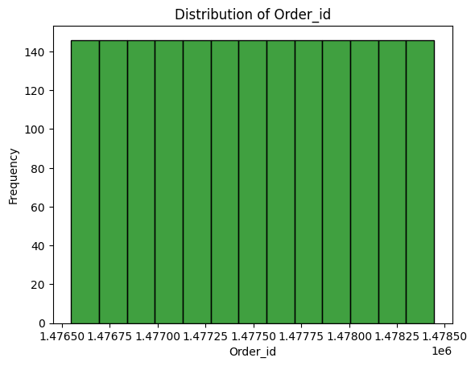

```python
# histogram distribution for order_id
sns.histplot(data=df, x='order_id', color='green')
plt.title('Distribution of Order_id')
plt.xlabel('Order_id')
plt.ylabel('Frequency');
```

Observations:

- Order_id distribution seems to be pretty standard across the board with not much variance in the amount of how many order_ids our dataset has.

### Customer_id

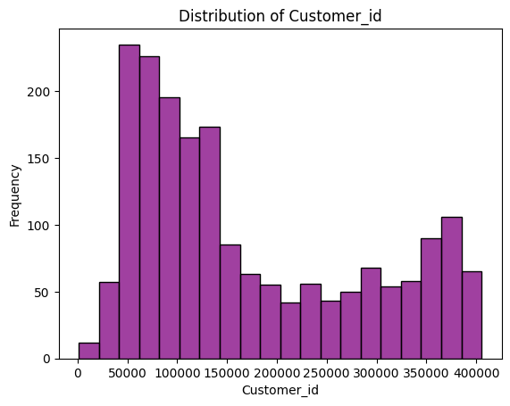

```python
# histogram distribution for customer_id
sns.histplot(data=df, x='customer_id', color='purple',bins=20)
plt.title('Distribution of Customer_id')
plt.xlabel('Customer_id')
plt.ylabel('Frequency');
```

Observations:

- While the customer_id histogram doesn't offer deep univariate insights, using customer_id is critical for multivariate analysis, such as identifying frequent customers, calculating average spending per customer, or understanding customer retention.

### Restaurant_name

```python
df['restaurant_name'].value_counts().head(10)
top_10_restaurants = df['restaurant_name'].value_counts().head(10)
print(top_10_restaurants)
```

```
restaurant_name
Shake Shack                      219
The Meatball Shop                132
Blue Ribbon Sushi                119
Blue Ribbon Fried Chicken         96
Parm                              68
RedFarm Broadway                  59
RedFarm Hudson                    55
TAO                               49
Han Dynasty                       46
Blue Ribbon Sushi Bar & Grill     44
Name: count, dtype: int64
```

```python
test = df['restaurant_name'].value_counts().head(10).reset_index()
test.head()
```

|  | restaurant_name | count |
| --- | --- | --- |
| 0 | Shake Shack | 219 |
| 1 | The Meatball Shop | 132 |
| 2 | Blue Ribbon Sushi | 119 |
| 3 | Blue Ribbon Fried Chicken | 96 |
| 4 | Parm | 68 |

### Cuisine_Type

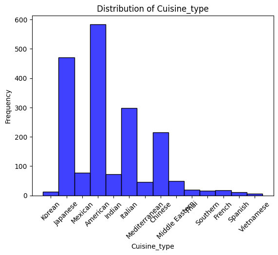

```python
# histogram distribution for cuisine_type
sns.histplot(data=df, x='cuisine_type', color='blue')
plt.title('Distribution of Cuisine_type')
plt.xlabel('Cuisine_type')
plt.ylabel('Frequency')
plt.xticks(rotation=45)
plt.show();
```

- American food seems to rank the highest for frequency of cuisine type ordered - followed by Japanese (2nd), and Italian (3rd).

### Cost_of_the_Order

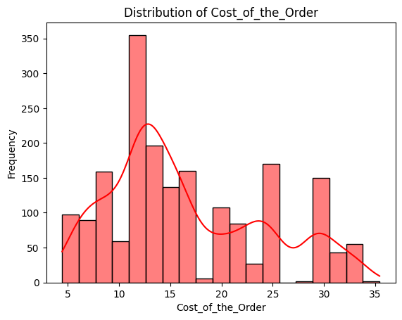

```python
# histogram distribution for cost_of_the_order
sns.histplot(data=df, x='cost_of_the_order', color='red', kde='true')
plt.title('Distribution of Cost_of_the_Order')
plt.xlabel('Cost_of_the_Order')
plt.ylabel('Frequency');
```

### Day_of_the_Week

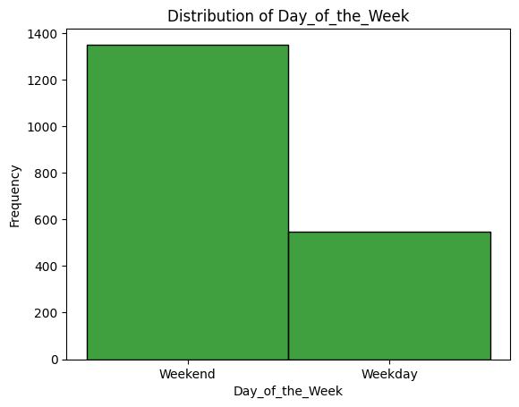

```python
# histogram distribution for day_of_the_week
sns.histplot(data=df, x='day_of_the_week', color='green')
plt.title('Distribution of Day_of_the_Week')
plt.xlabel('Day_of_the_Week')
plt.ylabel('Frequency');
```

- Interestingly enough, weekends tend to bring in a higher amount of orders.
  - could be due to the amount of people doing other activities on the weekends or a variety of other causes. Interested in exploring this further as well.

### Rating

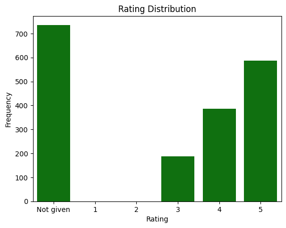

```python
#defined the rating order prior
rating_order = ['Not given', '1', '2', '3', '4', '5']

# countplot distribution for rating
sns.countplot(data=df, x='rating', color='green', order=rating_order)
plt.title('Rating Distribution')
plt.xlabel('Rating')
plt.ylabel('Frequency')
plt.figure(figsize=(8, 5))
plt.show();
```

- A higher amount of "Not Given" ratings are held than any other rating.
  - Could this be that people aren't finding it userful to go in and rate after receiving their food or forget to do so? If so, how can we improve the likelihood of our customers commiting to providing a rating, giving us more visibility into what may be working or what's not?

### Food_preparation_time

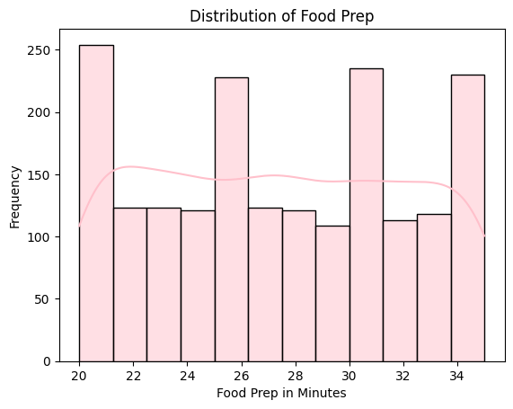

```python
# histogram distribution for food_preparation_time
sns.histplot(data=df, x='food_preparation_time', color='pink', kde='true')
plt.title('Distribution of Food Prep')
plt.xlabel('Food Prep in Minutes')
plt.ylabel('Frequency');
```

- There doesn't appear to be any major skewdness between less amount of food prep time and a higher amount of food prep time.
  - With 200+ occurences happening within the 20, 26, 30, and 34 minute timeframes.
  - We can also see the lack of variance from the kernel density line.

### Delivery_time

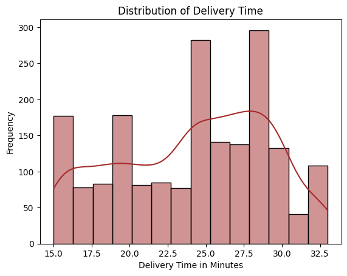

```python
# histogram distribution for delivery_time
sns.histplot(data=df, x='delivery_time', color='brown', kde='true')
plt.title('Distribution of Delivery Time')
plt.xlabel('Delivery Time in Minutes')
plt.ylabel('Frequency');
```

- There appears to be more of a concenctration for delivery times being between 25 - 28 minutes.
  - Could be worth exploring if this is dependent on restaurant type, proximity to customer, or whether certain restaurants tend to be farther from customer base.

### **Question 7**: Which are the top 5 restaurants in terms of the number of orders received? [1 mark]

```python
# break down the amount of orders for each restaurant name, then calculate the top 5 among those orders
restaurant_order_counts = df['restaurant_name'].value_counts()
```

```python
top_5_restaurants = restaurant_order_counts.head(5)
print("Top 5 restaurants by number of orders placed:")
print(top_5_restaurants)
```

```
Top 5 restaurants by number of orders placed:
restaurant_name
Shake Shack                  219
The Meatball Shop            132
Blue Ribbon Sushi            119
Blue Ribbon Fried Chicken     96
Parm                          68
Name: count, dtype: int64
```

### **Question 8**: Which is the most popular cuisine on weekends? [1 mark]

```python
# First filter out weekend orders, then filter out the cuisines ordered mainly on weekends, then filter it down to the top 5-10?
```

```python
weekend_orders = df[df['day_of_the_week']== 'Weekend']
```

```python
popular_cuisine_weekend = weekend_orders['cuisine_type'].value_counts()
```

```python
most_popular_cuisine = popular_cuisine_weekend.index[0]
print("The most popular cuisine type ordered on weekends is:")
print(popular_cuisine_weekend.head(5))

print("Overall, the #1 most popular cuisine type ordered on weekends is:")
print(popular_cuisine_weekend.head(1))
```

```
The most popular cuisine type ordered on weekends is:
cuisine_type
American    415
Japanese    335
Italian     207
Chinese     163
Mexican      53
Name: count, dtype: int64
Overall, the #1 most popular cuisine type ordered on weekends is:
cuisine_type
American    415
Name: count, dtype: int64
```

#### Observations:

- American is the most popular food type ordered on weekends. This fits closely to our above univariate analysis (both cuisine type and day of the week).

### **Question 9**: What percentage of the orders cost more than 20 dollars? [2 marks]

```python
# First understand the orders that cost more than $20, then filter out the number/length of that, and divide by total number of orders in the original dataframe.
```

```python
orders_above_20 = df[df['cost_of_the_order']>20]
```

```python
num_of_orders_above_20 = len(orders_above_20)
```

```python
total_orders = len(df)
```

```python
percentage_above_20 = round((num_of_orders_above_20/total_orders)*100)
```

```python
print(f"Number of orders costing more than 20 dollars: {num_of_orders_above_20}")
print(f"Total number of orders: {total_orders}")
print(f"Percentage of orders above 20 dollars: {percentage_above_20:.2f}%")
```

```
Number of orders costing more than 20 dollars: 555
Total number of orders: 1898
Percentage of orders above 20 dollars: 29.00%
```

#### Observations:

- This indicates that a third of orders are in a higher price bracket, which could be important for further observation to maximize revenue generation.
- Further understanding of this segment can help in tailoring promotions, loyalty/rewards programs for orders within this segment.
  - it could also indicate certain customers are willing to spend more, and possibly attribute to a positive sign for bsuiness growth.

### **Question 10**: What is the mean order delivery time? [1 mark]

```python
# calculate the mean/average delivery order time
```

```python
mean_delivery_time = df['delivery_time'].mean()
```

```python
print(f"The mean order delivery time is: {mean_delivery_time:.0f} minutes")
```

```
The mean order delivery time is: 24 minutes
```

#### Observations:

- The average time for deivery is 24 minutes - this is a decent time between order pickup and delivery
  - it is worth exploring further how this impacts customer satisfaction, and seeing how this works in tandem with preparation time. Delays going past this average could lead to negative ratings.

### **Question 11:** The company has decided to give 20% discount vouchers to the top 5 most frequent customers. Find the IDs of these customers and the number of orders they placed. [1 mark]

```python
# First calculate the count of orders per customer, then filter it to the top 5 most frequent customers.
customer_order_count = df['customer_id'].value_counts()
```

```python
top_5_customers = customer_order_count.head(5)
```

```python
print("Top 5 customers (IDs & total orders):")
print(top_5_customers)
```

```
Top 5 customers (IDs & total orders):
customer_id
52832     13
47440     10
83287      9
250494     8
259341     7
Name: count, dtype: int64
```

#### Observations:

- The top 5 customers are as shown above - with the top purchasing customer ID bringing in 13 orders total - higher than the next frequent customer ID.
  - The variance indicates a small group of customers who order at least once a week or every other week - making the incentive of a 20% off discount useful for them - possibly leading to more use of the app.

### **Question 12**: Perform a multivariate analysis to explore relationships between the important variables in the dataset. (It is a good idea to explore relations between numerical variables as well as relations between numerical and categorical variables) [10 marks]

### Food Preparation vs. Delivery Time

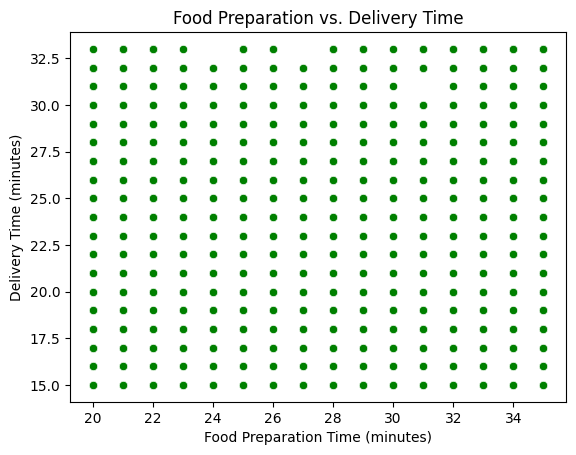

```python
sns.scatterplot(data=df, x='food_preparation_time', y='delivery_time', color = 'green')
plt.title('Food Preparation vs. Delivery Time')
plt.xlabel('Food Preparation Time (minutes)')
plt.ylabel('Delivery Time (minutes)')
plt.show();
```

### Cuisine Type vs. Cost of the Order

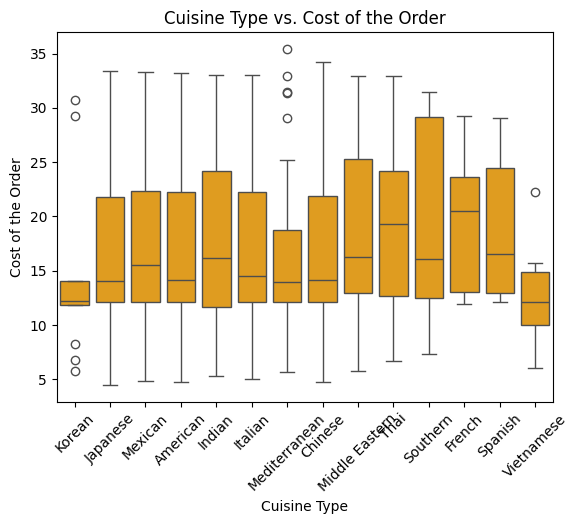

```python
sns.boxplot(data=df, x='cuisine_type', y='cost_of_the_order', color='orange')
plt.title('Cuisine Type vs. Cost of the Order')
plt.xlabel('Cuisine Type')
plt.ylabel('Cost of the Order')
plt.xticks(rotation=45)
plt.show();
```

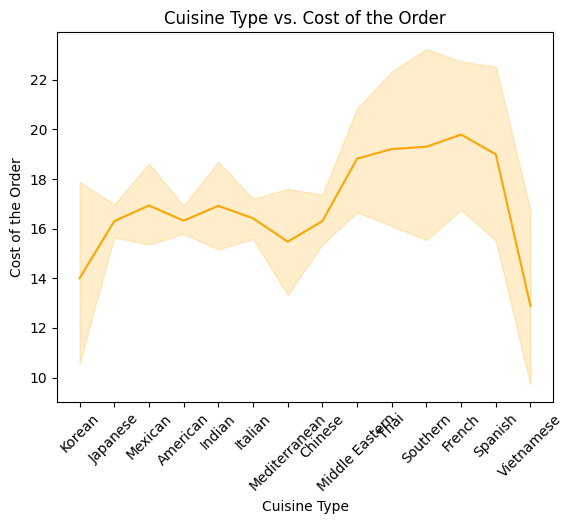

```python
sns.lineplot(data=df, x='cuisine_type', y='cost_of_the_order', color='orange')
plt.title('Cuisine Type vs. Cost of the Order')
plt.xlabel('Cuisine Type')
plt.ylabel('Cost of the Order')
plt.xticks(rotation=45)
plt.show();
```

### Observation

- French food has the highest median, while Vietnamese has the lowest median.
- Southern food tends to have a wider range of order costs, while Korean food tends to have a more consistent pricing model across all menu options.
- Meditteranean has the most amount of outliers, which could mean this could be a result of specialty items causing for such a high amount of outliers, or large orders (i.e., catering, food ordered for large groups and parties).
  - These findings could influence pricing strategies, and promotinal offers for specified cuisine type within the app.

### Day of the Week vs. Total Order Time

```python
total_prep_time = df['food_preparation_time'].sum()
total_delivery_time = df['delivery_time'].sum()
total_order_time = total_prep_time + total_delivery_time
df['total_order_time'] = df['food_preparation_time'] + df['delivery_time']
print(df[['food_preparation_time', 'delivery_time', 'total_order_time']].head())
```

```
   food_preparation_time  delivery_time  total_order_time
0                     25             20                45
1                     25             23                48
2                     23             28                51
3                     25             15                40
4                     25             24                49
```

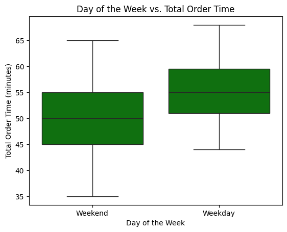

```python
sns.boxplot(data=df, y='total_order_time', x = 'day_of_the_week', color='green')
plt.title('Day of the Week vs. Total Order Time')
plt.xlabel('Day of the Week')
plt.ylabel('Total Order Time (minutes)')
plt.show();
```

### Observation

- The total order time (food preparation + delivery time) is significantly higher on weekdays compared to weekends, wehre the total time is shortened.
  - This could be because of more readily available drivers to deliver the food in those areas or an increase in staff at the restaurants during the weekend, leading to quicker response and prep times for food preapartion.
  - There could be an opportunity for incentives/rewards for ordering on the weekends if FoodHub wants to increase those numbers, considering that is when our customers typically are using the app.
    - OR a chance to increase weekday rewards by offering incentives for days that fall within a weekday to increase or distribute our numbers throughout the entire week.

### Cuisine Type vs. Food Preparation Time

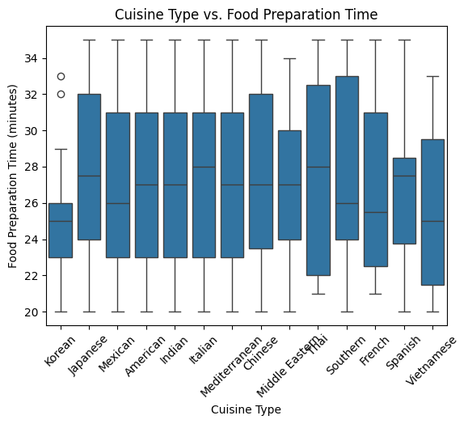

```python
sns.boxplot(data=df, x='cuisine_type', y='food_preparation_time')
plt.title('Cuisine Type vs. Food Preparation Time')
plt.xlabel('Cuisine Type')
plt.ylabel('Food Preparation Time (minutes)')
plt.xticks(rotation=45)
plt.show();
```

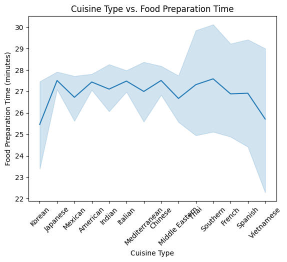

```python
sns.lineplot(data=df, x='cuisine_type', y='food_preparation_time')
plt.title('Cuisine Type vs. Food Preparation Time')
plt.xlabel('Cuisine Type')
plt.ylabel('Food Preparation Time (minutes)')
plt.xticks(rotation=45)
plt.show();
```

### Observations:

- Identifies which cuisine type requires more or less time for food preparation. Italian and Thai have the highest median, while Korean food maintains the lowest time for food prep.
- However, Thai food has the highest variability for IQR, meaning that certain foods (depending on what is typically being ordered) might take more time to prepare or relatively quick.
  - honorable mention for Vietnamese food and it's variability as well.

### Day of the Week vs. Cost of the Order

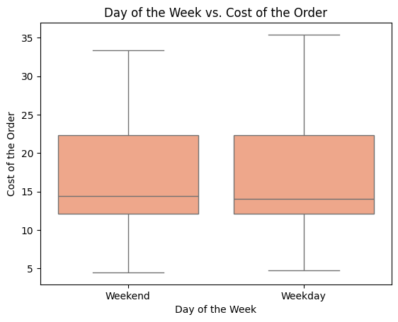

```python
sns.boxplot(data=df, x='day_of_the_week', y='cost_of_the_order', color='lightsalmon', legend=False)
plt.title('Day of the Week vs. Cost of the Order')
plt.xlabel('Day of the Week')
plt.ylabel('Cost of the Order');
```

### Observations:

- It appears that the average order cost tends to remain consistent throughout the week (not much changing from weekday to weekend).

### Rating vs. Total Order Time

```python
df_rated = df[df['rating'] != 'Not given'].copy()
df_rated['rating'] = df_rated['rating'].astype(int)
```

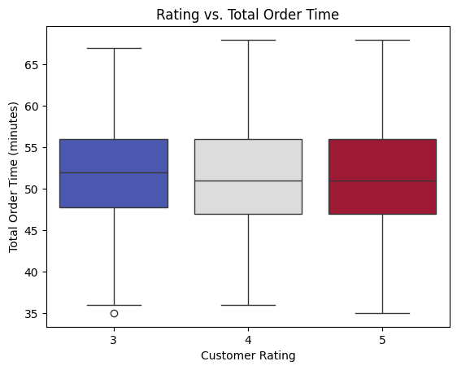

```python
sns.boxplot(data=df_rated, x='rating', y='total_order_time', palette='coolwarm', hue='rating', legend=False)
plt.title('Rating vs. Total Order Time')
plt.xlabel('Customer Rating')
plt.ylabel('Total Order Time (minutes)')
plt.figure(figsize=(15, 7))
plt.show();
```

### Observations:

- Similar to the day of the week/order cost, customer rating and total order time don't tend to offset one or the other. Lower ratings don't significantly correlate with longer order times just the same as higher ratings don't significantly correlate with shorter order times.

### Correlation Heatmap

```python
numerical_df = df[['cost_of_the_order', 'food_preparation_time', 'delivery_time', 'total_order_time']]
correlation_matrix = numerical_df.corr()
```

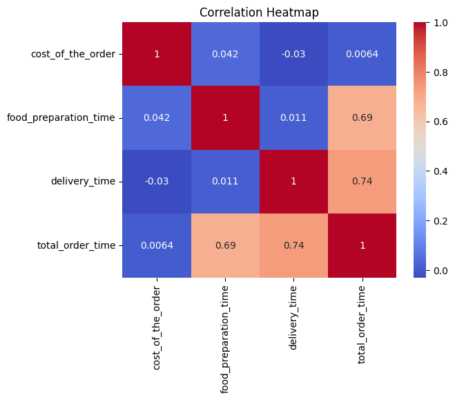

```python
sns.heatmap(correlation_matrix, annot=True, cmap='coolwarm')
plt.title('Correlation Heatmap')
plt.show();
```

### Observations

- This heatmap visualizes the correlation matrix between each pair of numerical variables within our data.
- There is a strong positive correlation between food_preparation_time & total_order_time, as well as delivery_time & total_order_time, because our total_order_time is the summation of the two. This further confirms our calculations.

### **Question 13:** The company wants to provide a promotional offer in the advertisement of the restaurants. The condition to get the offer is that the restaurants must have a rating count of more than 50 and the average rating should be greater than 4. Find the restaurants fulfilling the criteria to get the promotional offer. [3 marks]

```python
# Process used to calculate rated restaurants (excluding "Not given"), then converting to interger. From there, group the restaurants and necessary information (count and mean), and then calculate all information combined to show restaurant names, counts > 50 and mean > 4
df_rated_restaurants = df[df['rating'] != 'Not given'].copy()
df_rated_restaurants['rating']= df_rated_restaurants ['rating'].astype(int)
restaurant_ratings = df_rated_restaurants.groupby('restaurant_name')['rating'].agg(['count', 'mean'])
promotional_restaurants = restaurant_ratings[(restaurant_ratings['count']>50) & (restaurant_ratings['mean']>4)]
print('Restaurants that fulfill the criteria for the promotinal offer are:')
print(promotional_restaurants)
```

```
Restaurants that fulfill the criteria for the promotinal offer are:
                           count      mean
restaurant_name
Blue Ribbon Fried Chicken     64  4.328125
Blue Ribbon Sushi             73  4.219178
Shake Shack                  133  4.278195
The Meatball Shop             84  4.511905
```

#### Observations:

- The results don't come with any surprise, because these are the same restaurants (with different counts) that we discovered earlier as our top producing restaurant analysis.
- Even with varying counts of ratings received, they still score similar ratings - relatively close to one another.

### **Question 14:** The company charges the restaurant 25% on the orders having cost greater than 20 dollars and 15% on the orders having cost greater than 5 dollars. Find the net revenue generated by the company across all orders. [3 marks]

```python
def rev(x):
  if x > 20:
    return x * 0.25
  elif x > 5:
    return x * 0.15
  else:
    return x * 0
df['revenue'] = df['cost_of_the_order'].apply(rev)
df.head()
```

|  | order_id | customer_id | restaurant_name | cuisine_type | cost_of_the_order | day_of_the_week | rating | food_preparation_time | delivery_time | total_order_time | revenue |
| --- | --- | --- | --- | --- | --- | --- | --- | --- | --- | --- | --- |
| 0 | 1477147 | 337525 | Hangawi | Korean | 30.75 | Weekend | Not given | 25 | 20 | 45 | 7.6875 |
| 1 | 1477685 | 358141 | Blue Ribbon Sushi Izakaya | Japanese | 12.08 | Weekend | Not given | 25 | 23 | 48 | 1.8120 |
| 2 | 1477070 | 66393 | Cafe Habana | Mexican | 12.23 | Weekday | 5 | 23 | 28 | 51 | 1.8345 |
| 3 | 1477334 | 106968 | Blue Ribbon Fried Chicken | American | 29.20 | Weekend | 3 | 25 | 15 | 40 | 7.3000 |
| 4 | 1478249 | 76942 | Dirty Bird to Go | American | 11.59 | Weekday | 4 | 25 | 24 | 49 | 1.7385 |

```python
print(f"Net revenue generated by the company across all orders is ${round(df['revenue'].sum(),2)}")
```

```
Net revenue generated by the company across all orders is $6166.3
```

```python
# alternative method for calculating the total net revenue
revenue_above_20 = (df[df['cost_of_the_order'] > 20]['cost_of_the_order']* .25).sum()
revenue_between_5_and_20 = (df[(df['cost_of_the_order'] > 5) & (df['cost_of_the_order']<= 20)]['cost_of_the_order']* .15).sum()
net_revenue = revenue_above_20 + revenue_between_5_and_20
print(f"Revenue from orders costing more than $20: ${revenue_above_20:.2f}")
print(f"Revenue from orders costing between $5 and $20 (inclusive): ${revenue_between_5_and_20:.2f}")
print(f"Total Net Revenue generated: ${net_revenue:.2f}")
```

```
Revenue from orders costing more than $20: $3688.73
Revenue from orders costing between $5 and $20 (inclusive): $2477.58
Total Net Revenue generated: $6166.30
```

### Observations:

- The total net revenue indicates the amount of earnings FoodHub acquired from the orders of 2 different structures.
- Knowing this breakdown can help FoodHub understand which segments for price contribute to most of it's revenue, and further adjust/understand potetnail marketing efforts.

### **Question 15:** The company wants to analyze the total time required to deliver the food. What percentage of orders take more than 60 minutes to get delivered from the time the order is placed? (The food has to be prepared and then delivered.) [2 marks]

```python
# First determine total order time, then determine how many of those are over 60 minutes total. From there, calculate the number of orders over 60, and divide by the total number of orders in the dataset to uncover the percentage.
df[total_order_time] = df['delivery_time'] + df['food_preparation_time']
orders_over_60_minutes = df[df['total_order_time']>60]
num_orders_over_60_minutes = len(orders_over_60_minutes)
total_orders= len(df)
percentage_of_orders_over_60 = (num_orders_over_60_minutes/total_orders)*100
print (f"Number of orders over 60 minutes: {num_orders_over_60_minutes}")
print(f"Number of total orders: {total_orders}")
print(f"Percentage of orders that take more than 60 minutes to get delivered is: {percentage_of_orders_over_60:.2f}%")
```

```
Number of orders over 60 minutes: 200
Number of total orders: 1898
Percentage of orders that take more than 60 minutes to get delivered is: 10.54%
```

#### Observations:

- The percentage indicates to us the rate of how often customers are experiencing total order times exceeding that of 60 minutes (1 hr). A higher percentage of orders exceeding 60 minutes could lead to higher customer dissatisfaction.
- This metric could help FoodHub identify areas of improvement to reduce delivery times or pinpoint reasons for orders meeting &/or exceeding this threshold.

### **Question 16:** The company wants to analyze the delivery time of the orders on weekdays and weekends. How does the mean delivery time vary during weekdays and weekends? [2 marks]

```python
# calculate the average delivery times for both weekend and weekdays
mean_delivery_time_weekend = df[df['day_of_the_week']== "Weekend"]['delivery_time'].mean()
mean_delivery_time_weekday = df[df['day_of_the_week']== "Weekday"]['delivery_time'].mean()
print(f"The average delivery time for weekday deliveries is: {mean_delivery_time_weekday:.0f} minutes")
print(f"The average delivery time for weekend deliveries is: {mean_delivery_time_weekend:.0f} minutes")
```

```
The average delivery time for weekday deliveries is: 28 minutes
The average delivery time for weekend deliveries is: 22 minutes
```

#### Observations:

- There is a distinct difference in mean delivery times, with weekend deliveries being significantly faster (around 22 minutes) compared to weekday deliveries (around 28 minutes).
- This should be further investigated, but could be caused by the following:
  - **Higher Driver Availability**: More delivery personnel might be working on weekends to meet anticipated higher demand, leading to better allocation and quicker pick-ups/drop-offs.
  - **Less Traffic Congestion**: While centered in New York, weekend traffic patterns might be less congested than New York's regular weekday rush hours, allowing for faster travel times.
- **Implications for Weekday Deliveries**: The longer weekday delivery times could indicate:
  - **Fewer Available Drivers**: Insufficient delivery personnel during weekdays might stretch delivery times.
  - **Increased Road Congestion**: Commute traffic during weekdays can naturally slow down delivery speeds.
  - **Restaurant Capacity**: Restaurants might face more dine-in or other order types during weekdays, potentially impacting the efficiency of FoodHub orders.

### Conclusion and Recommendations

### **Question 17:** What are your conclusions from the analysis? What recommendations would you like to share to help improve the business? (You can use cuisine type and feedback ratings to drive your business recommendations.) [6 marks]

```python
# check for average order amount spent
average_spend_on_orders = df['cost_of_the_order'].mean()
print(f"Average spend on orders: ${average_spend_on_orders:.0f}")
```

```
Average spend on orders: $16
```

### Conclusions:

- Customer Base: Overall customer base geared towards patrons of New York, studens, working professionals, party hosters, etc.
- Overview of Stats:
  - Total Number of Orders: 1898
  - Net Revenue Generated: $6,166.30
  - Most Popular Cuisine: American
  - Most Popular Day of the Week to Order: Weekends
  - Top Performing Restaurant: Shake Shack
  - Average Delivery Time: 24 minutes
- Customer Behavior Insights: From our findings, we can see that -
  - Average Spent on Individual Orders: $16
  - Unrated orders: 736
  - Top 5 Frequent Customers (customer loyalty):
    - 52832 | 47440 | 83287 | 250494 | 259341

### Recommendations:

Enhancing Customr Experience & Engagement:

- Improve Customer Ratings Engagement -
  - It could be a good idea to introduce post-delivery reminders (“Rate your meal and earn 5 reward points”).
  - Provide micro-incentives such as $5 off next order for rating that have been provided in 10 minutes.
  - Add a one-tap rating option to reduce friction and commitment to time spent in the rating experience.

Optimizing Restaurant Operations & Delivery Based on Prep Times:

- Suggest participating restaurants pre-prep popular items during peak hours.
- Encourage popular restaurants to use FoodHub's “estimated prep-time feedback” to optimize staffing and improve overall customer experience/satisfaction.
- Highlight fast-prep cuisines (cuisines) in the UI with labels like “Quick Bites” to maximize picks and emphasize these picks at peak production portions of the day (i.e., lunc time).

Stregthen High - Value Customer Retention:

- Possibly implement a loyalty tier program (i.e., free delivery after every 5 orders).
- Provide personalized offers to some of our top customers, like discounts on their most-ordered cuisine.
- Encourage referrals (loyal customers → new customers).

Manage Weekday vs. Weekend Demand:

- It could be a good idea to increase delivery partner availability on the weekdays to maintain fast delivery times.
- Run weekday-only promotions to spread the upcoming demand (i.e., “$3 Off Thursday”).
- Business Model & Revenue Strategy:

Increase Profit form High - Value Orders:

- Create premium upsell prompts (“Add dessert +$6”).
- Promote bundled meals for customers already spending above $20.